# Investigation of loan data from Prosper

### Investigation Overview

In this project I want to explore the characteristics of loans from the peer-to-peer loan marketplace [Prosper](https://www.prosper.com/). The Investigation will we centered around four questions:

- What causes people to take loans in the first place?
- What determines a borrowers apr (average percentage rate (interest rate + fees))?
- What affects the probabilities for different outcomes?
- Did the average apr change over time?

### Dataset Overview

The dataset contains information for 105.000 transactions across 20 columns. Around 8.000 rows and 60 columns were removed from the original DataFrame for quality and tidiness purposes.

## Part 1: What causes people to take loans in the first place?

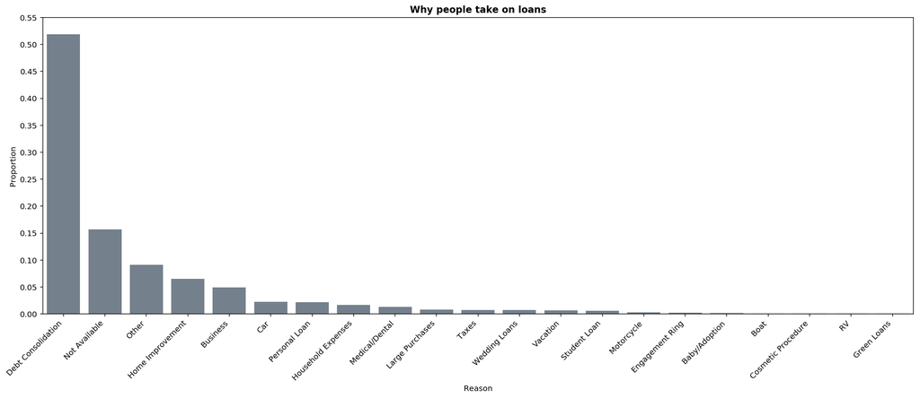

```python
n = df.reason.count()
n_max = df.reason.value_counts().max()
p_max = n_max / n
ticks = np.arange(0, p_max + 0.05, 0.05)
labels = ['{:.2f}'.format(v) for v in ticks]
order = df.reason.value_counts().index
base_color = '#708090'

plt.figure(figsize = (20, 7))
sns.countplot(data = df, x = 'reason', order = df.reason.value_counts().index, color = base_color)
plt.xticks(rotation = 45, ha = 'right')
plt.yticks(ticks * n, labels)
plt.ylabel('Proportion')
plt.xlabel('Reason')
plt.title('Why people take on loans', fontsize = 12, weight = 'bold');
```

More than 50 percent of all borrowers take on a loan to pay other loans. This characteristic might be worth a further investigation as debt consolidation comes along with some major risks.

#### More than than 50 percent of all borrowers take on a loan to pay other loans, so most borrowers should have already used a fair amount of their CreditCard line?

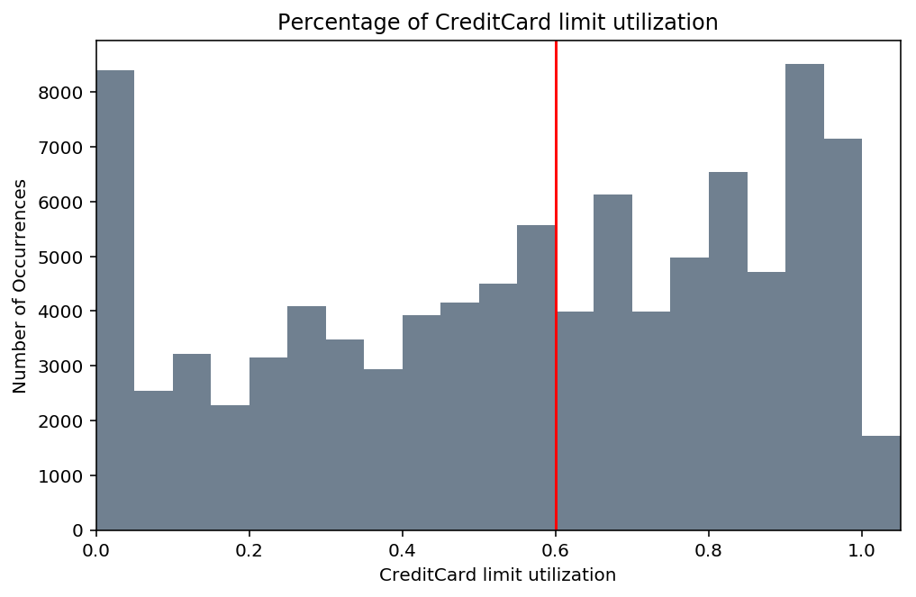

```python
# exclude NaN and any values higher than 1.1 to be able to plot the histogram
credit_df = df[(df['credit_utilization'].notnull()) & (df['credit_utilization'] < 1.1)]

plt.figure(figsize = (8, 5))
plt.hist(credit_df.credit_utilization, bins = np.arange(0, 1.1, 0.05), color = base_color)
plt.xlim(0, 1.05)
plt.axvline(credit_df.credit_utilization.median(), color = 'r')
plt.title('Percentage of CreditCard limit utilization')
plt.xlabel('CreditCard limit utilization')
plt.ylabel('Number of Occurrences');
```

And indeed, the above histogram underlines this issue. The red line marks the median Borrowers CreditCard limit utilization. Despite the decent amount of people who did not make use of any of their CreditCard debt, 50 percent of all borrowers have already used more than 60% of their CreditCard limit.

#### What is the total debt-to-income ratio of borrowers?

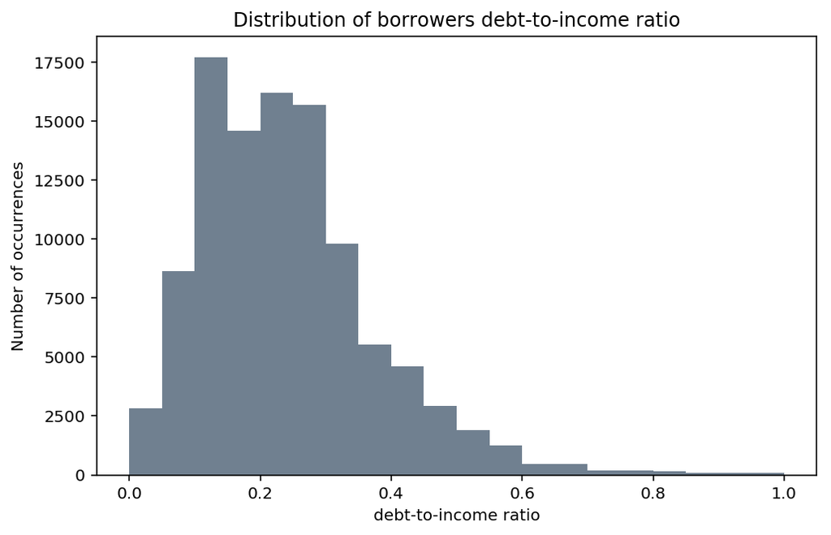

```python
debt = df[(df['debt_ratio'].notnull()) & (df['debt_ratio'] < 1.01)]

plt.figure(figsize = (8, 5))
plt.hist(debt.debt_ratio, bins = np.arange(0, 1 + 0.05, 0.05), color = base_color)
plt.title('Distribution of borrowers debt-to-income ratio')
plt.xlabel('debt-to-income ratio')
plt.ylabel('Number of occurrences');
```

## Part 2: What determines the borrowers apr?

#### How does the credit rating affect a borrowers apr?

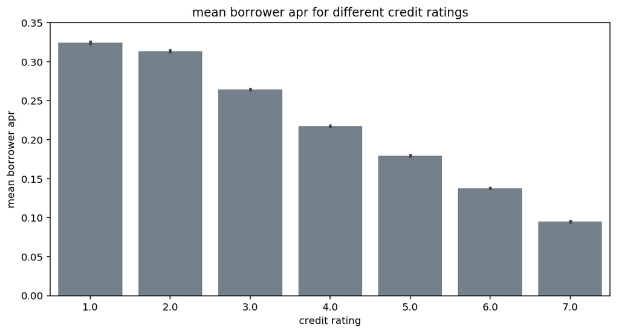

```python
data = df[df['credit_rating'] != 0] # exclude credit rating of 0 (NaN)

plt.figure(figsize = (10, 5))
sns.barplot(data = data, x = 'credit_rating', y = 'borrower_apr', color = base_color)
plt.ylim([0, 0.35])
plt.title('mean borrower apr for different credit ratings')
plt.ylabel('mean borrower apr')
plt.xlabel('credit rating');
```

#### Are homeowners offered a lower apr?

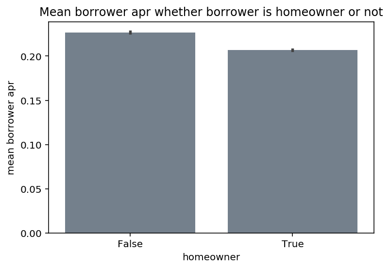

```python
sns.barplot(data = df, x = 'homeowner', y = 'borrower_apr', color = base_color)
plt.title('Mean borrower apr whether borrower is homeowner or not')
plt.ylabel('mean borrower apr');
```

#### Does the occupation affect the apr?

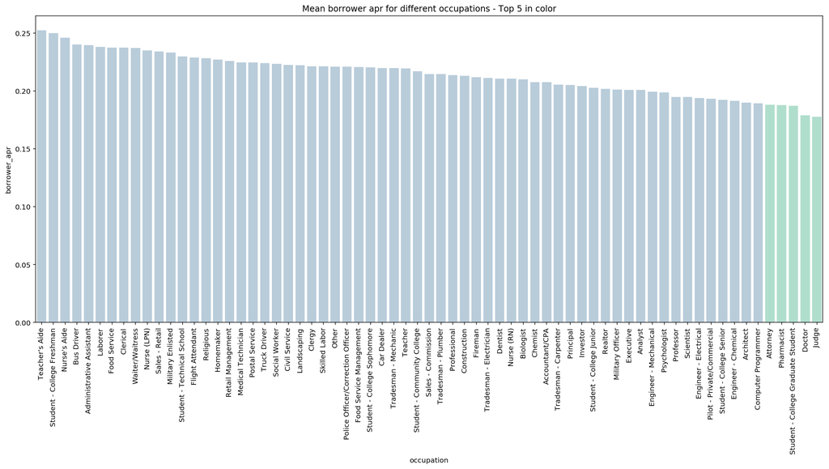

```python
occupation_df = df.groupby('occupation').mean().reset_index().sort_values('borrower_apr', ascending = False)
occupation_list = list(occupation_df.occupation.tail())

clrs = ['#a8e6cf' if (x in occupation_list) else '#b3cde0' for x in occupation_df.occupation]

plt.figure(figsize = (20, 8))
sns.barplot(data = df, x = 'occupation', y = 'borrower_apr', order = occupation_df['occupation'], palette = clrs, ci = None)
plt.title('Mean borrower apr for different occupations - Top 5 in color')
plt.xticks(rotation = 90);
```

#### What about the state the borrower lives in?

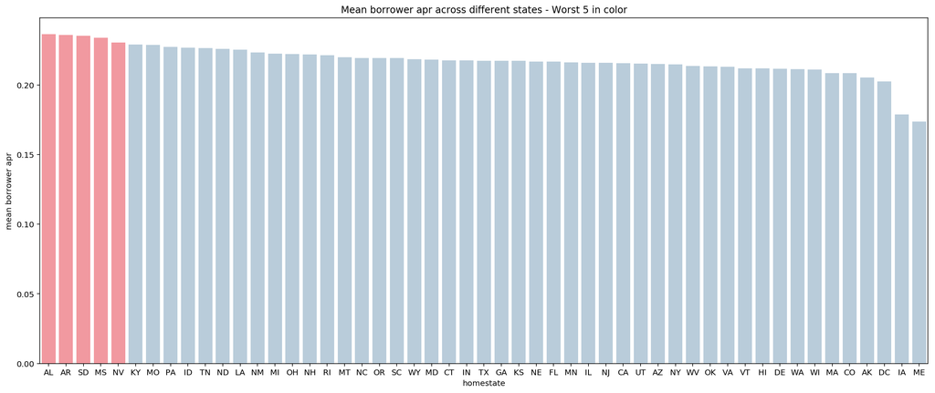

```python
clrs = ['#ff8b94' if (x in ['AL', 'AR', 'SD', 'MS', 'NV']) else '#b3cde0' for x in homestate_df.homestate]
plt.figure(figsize = (20, 8))
sns.barplot(data = df, y = 'borrower_apr', x = 'homestate', order = homestate_df['homestate'], palette = clrs, ci = None)
plt.title('Mean borrower apr across different states - Worst 5 in color')
plt.ylabel('mean borrower apr');
```

## Part 3: What affects the probabilities for different outcomes?

#### What are the propabilities for a loan to defaulted or be chargedoff?

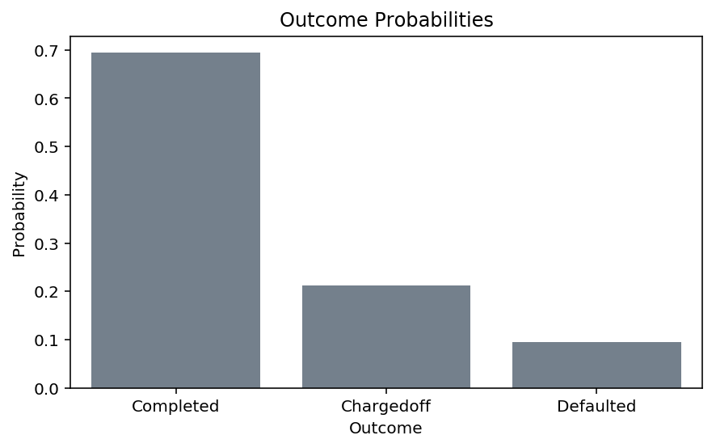

```python
outcome_df = df[df['status'].isin(['Completed', 'Chargedoff', 'Defaulted'])]

n = outcome_df.status.count()
n_max = outcome_df.status.value_counts().max()
p_max = n_max / n
ticks = np.arange(0, p_max + 0.1, 0.1)
labels = ['{:.1f}'.format(v) for v in ticks]
order = outcome_df.status.value_counts().index

plt.figure(figsize = (7, 4))
sns.countplot(outcome_df.status, color = base_color, order = order)
plt.yticks(ticks * n, labels)
plt.title('Outcome Probabilities')
plt.ylabel('Probability')
plt.xlabel('Outcome');
```

70 percent of all loans get payed back, around 20 percent get charged off and 10 percent default.

#### What is the relationship between credit rating and outcome?

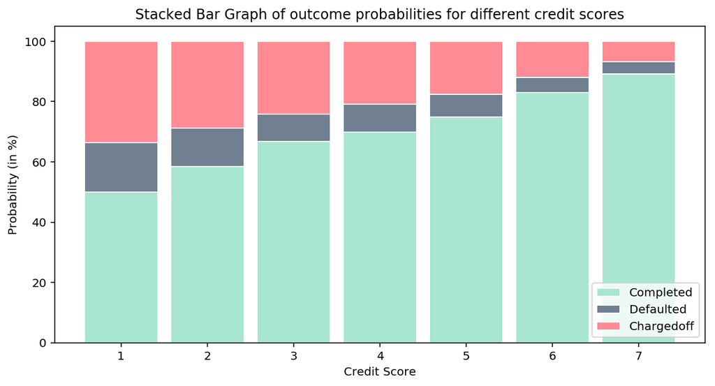

```python
# Query the outcome df to only include the columns status and credit_rating
query = outcome_df[['status', 'credit_rating']]
# Exclude credit rating 0 (equivalent to NaN)
query = query[query['credit_rating'] != 0]
# groupby credit rating and status to get get a df with the count for each status
groupby_credit_rating = query.groupby(['credit_rating', 'status']).size().reset_index()

# create lists which contain the values for each category for each rating
completed = list(groupby_credit_rating.query('"Completed" in status')[0])
defaulted = list(groupby_credit_rating.query('"Defaulted" in status')[0])
chargedoff = list(groupby_credit_rating.query('"Chargedoff" in status')[0])

# construct a new df used for the stacked bar graph
raw_data = {'Completed': completed, 'Defaulted': defaulted, 'Chargedoff': chargedoff}
outcome_stacked = pd.DataFrame(raw_data)

# convert the values from absolute to percentage
totals = [i + j + k for i, j, k in zip(outcome_stacked['Completed'], outcome_stacked['Defaulted'],\
                                       outcome_stacked['Chargedoff'])]
Completed = [i / j * 100 for i, j in zip(outcome_stacked['Completed'], totals)]
Defaulted = [i / j * 100 for i, j in zip(outcome_stacked['Defaulted'], totals)]
Chargedoff = [i / j * 100 for i, j in zip(outcome_stacked['Chargedoff'], totals)]

r = [1, 2, 3, 4, 5, 6, 7]

# plot the stacked bar graph
width = 0.85

plt.figure(figsize = (10, 5))

plt.bar(r, Completed, color = '#a8e6cf', edgecolor = 'white', width = width, label = 'Completed')
plt.bar(r, Defaulted, bottom = Completed, color = base_color, edgecolor = 'white', width = width, label = 'Defaulted')
plt.bar(r, Chargedoff, bottom = [i + j for i, j in zip(Completed, Defaulted)], color = '#ff8b94',\
        edgecolor = 'white', width = width, label = 'Chargedoff')

plt.title('Stacked Bar Graph of outcome probabilities for different credit scores')
plt.legend(loc = 'lower right')
plt.xlabel('Credit Score')
plt.ylabel('Probability (in %)');
```

#### Is the outcome associated with the borrowers apr?

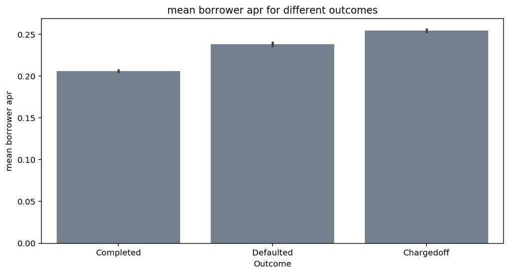

```python
plt.figure(figsize = (10, 5))
sns.barplot(data = outcome_df, x = 'status', y = 'borrower_apr', color = base_color)
plt.title('mean borrower apr for different outcomes')
plt.xlabel('Outcome')
plt.ylabel('mean borrower apr');
```

## Part 4: Did the average apr change over time?

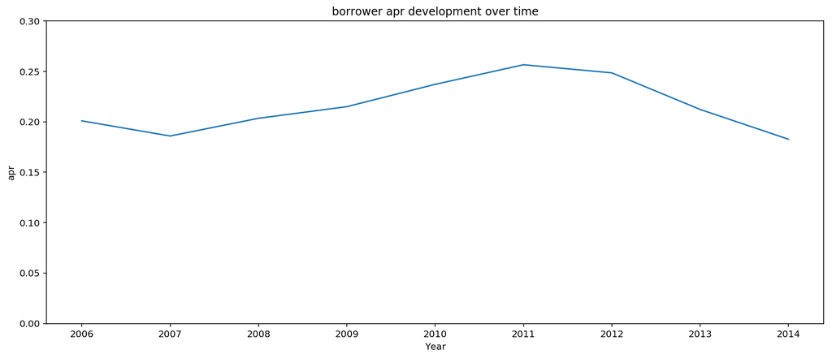

```python
groupby_year = df.groupby(df.date.dt.year).mean().reset_index()
plt.figure(figsize = (15, 6))
plt.plot(groupby_year.date, groupby_year.borrower_apr)
plt.ylim([0, 0.3])
plt.title('borrower apr development over time')
plt.xlabel('Year')
plt.ylabel('apr');
```